# Differential Expression Analysis

ALSF CCDL - Candace Savonen

9/18/18

*Purpose*: This notebook takes data and metadata from refine.bio and identifies differentially expressed genes. This script is very generally applicable to pre-processed RNA-Seq or microarray data.

## 1) Install libraries

This script uses the bioconductor R package limma to identify differentially expressed genes.  
The full guide on [limma](https://bioconductor.org/packages/release/bioc/vignettes/limma/inst/doc/usersguide.pdf) shows examples of limma functions. *Citation*: Ritchie ME, Phipson B, Wu D, Hu Y, Law CW, Shi W, Smyth GK (2015). “limma powers differential expression analyses for RNA-sequencing and microarray studies.” Nucleic Acids Research, 43(7), e47.

```r
# Install limma
source("https://bioconductor.org/biocLite.R")
```

```
## Bioconductor version 3.7 (BiocInstaller 1.30.0), ?biocLite for help
```

```
## A newer version of Bioconductor is available for this version of R,
##   ?BiocUpgrade for help
```

```r
biocLite("limma", suppressUpdates = TRUE)
```

```
## BioC_mirror: https://bioconductor.org
```

```
## Using Bioconductor 3.7 (BiocInstaller 1.30.0), R 3.5.1 (2018-07-02).
```

```
## Installing package(s) 'limma'
```

```r
# Attach library
library(limma)
```

## 2) Import and set up data

Data downloaded from refine.bio include a metadata tab separated values (“tsv”) file and a data tsv file. This chunk of code will read the both tsv files and add them as data.frames to your environment.

```r
# Read in metadata tsv file
metadata <- read.delim(file.path("..", "data", "metadata_GSE71270.tsv"),
                       header = TRUE)

# Read in data tsv file
df <- read.delim(file.path("..", "data", "GSE71270.tsv"), header = TRUE,
                 row.names = 1, stringsAsFactors = FALSE)
```

## 3) Set up design matrix

```r
# Check if the samples are in the same order in the metadata and data files
# Have to use gsub to get rid of problematic punctuation and space so they are
# matching
tmp <- match(gsub("X|\\.", "", colnames(df)), metadata$geo_accession)

# Use the indices identified in the line above to rearrange the design matrix to
# be in the same order as the data
# Create the design matrix
des.mat <- model.matrix(~metadata$genotype.variation[tmp])
```

## 3) Apply linear model

After applying our data to linear model, in this example we apply empircal Bayes smoothing and Benjamini-Hochberg multiple testing correction. The `topTable` function default is to use Benjamini Hochberg but this can be changed to a different method using the `adjust.method` argument.

```r
# Apply linear model to data
fit <- lmFit(df, design = des.mat)

# Apply empirical Bayes to smooth standard errors
fit <- eBayes(fit)

# Apply multiple testing correction and obtain stats
stats <- topTable(fit, number = nrow(df))
```

```
## Removing intercept from test coefficients
```

## 4) Explore fitness of model

Here we will use two different plots that can be used to assess the quality of your model. A guide to the interpretation of these plots and other statistics for gene expression data can be found [here](http://www.nathalievialaneix.eu/doc/pdf/tutorial-rnaseq.pdf).

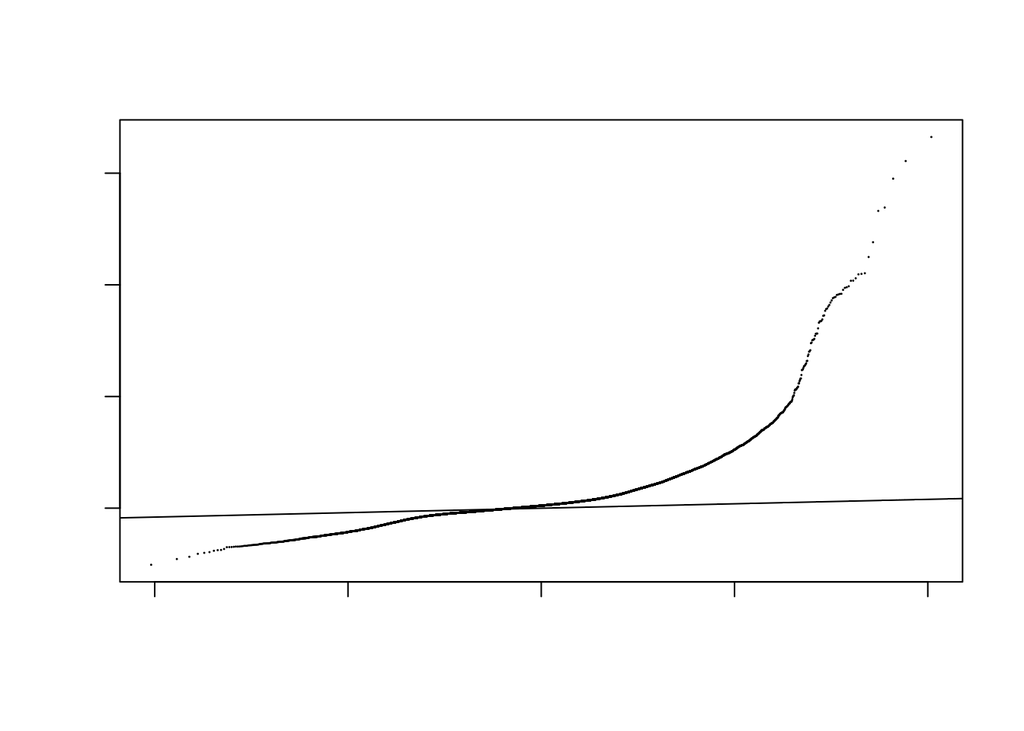

```r
# Create Q-Q plot
qqt(fit$t, pch = 16, cex = 0.2);
abline(0,1)
```

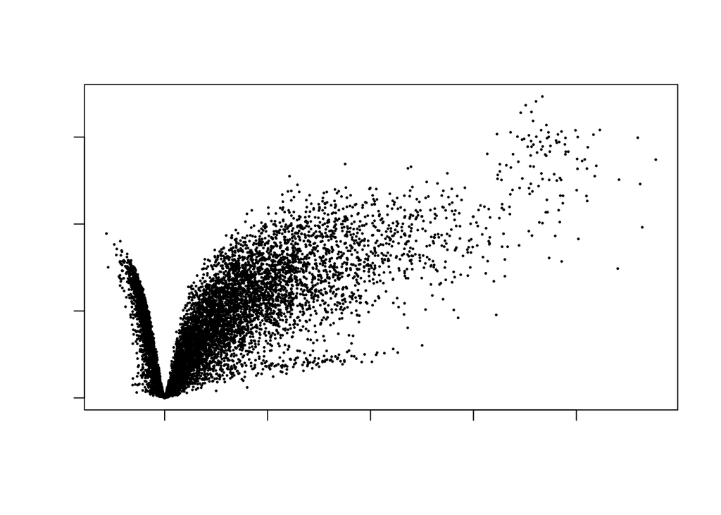

```r
# Create volcano plot
volcanoplot(fit, main = "Volcano Plot")
```

## 5) Write statistics to output results file

```r
write.table(stats, file = "GSE71270limmaResults.tsv", sep = "\t", quote = FALSE)
```